# Introduction to Machine Learning

## Session Objectives and Transferable Skills

- Provide a theoretical overview of Tree-based Machine Learning Techniques.
- Provide a technical and practical overview of Decision Trees for Classification and Regression Problems.
- Understand how to interpret these models and evaluate them.
- Understand how to design, develop, and interpret Tree-based Machine Learning Models in R.
- Using the packages tidyverse, caret & rpart.

## Schedule

- Introduction (5 minutes)
- Part 1: (45 minutes)
  - Introduction to Machine Learning (Theory)
  - What are tree-based models, what variations exist. (Theory)
  - How to Prepare data for ML (Practical, Section 1)
  - Growing your first decision Tree (Practical, Section 2)
- Break (5 minutes)
- Part 2: (35 minutes)
  - How to read, and interpret, Decision Trees (Theory)
  - Evaluating Trees in Practice (Practical, Section 3)
  - Reviewing & Comparing models (Practical, Section 4)

## Introduction

- Content in this session will build upon content covered in this [book](https://www.statlearning.com/).
- I won’t use any of the exercises or code examples covered in this book, so check them out for an alternative or further challenge!
- For Tree-Based Models, check out Chapter 8.

[figure not shown]

## Part 1

## Introduction to Machine Learning

- Aim to address classification or regression problems
- Through predicting future outcomes based upon previous data.
- Techniques are classified either as:
  - Supervised Techniques
  - Unsupervised Techniques

## Introduction to Machine Learning

- Supervised Techniques:
  - Tree-based Models
  - Support Vector Machines (SVM)
  - Neural Networks
  - General Linear Models
- Generally problem focused approaches, with defined input & output variables

## Introduction to Machine Learning

- Unsupervised Techniques:
  - K-Means or K-Medoids
  - Gaussian Mixtures
  - Neural Networks
- Generally exploratory focused approaches, with non-defined input & output variables

## What are Tree-Based Models

- Techniques which result in models which look generally like *trees*
- Of which decision trees, are the most simplistic form and can be considered the semantic base of all other models.
- Describe the outcome feature space, through grouping, segmentation or stratifying by the predictors provided,
- Achieved through generating binary splits in the feature space until the simplest spaces or groups are made

## What are Tree-Based Models

[figure not shown]

## Part 2

## Reading & Interpreting Decision Trees

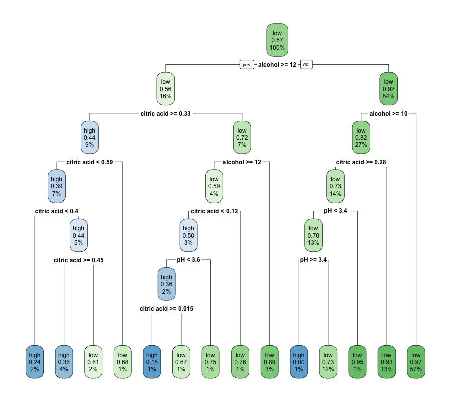

## Reading & Interpreting Decision Trees

- **Root Node** - The top of the Tree, aka the first node
- **Decision Node** - A node where a split (or decision) occurs
- **Terminal Node** - An ending node

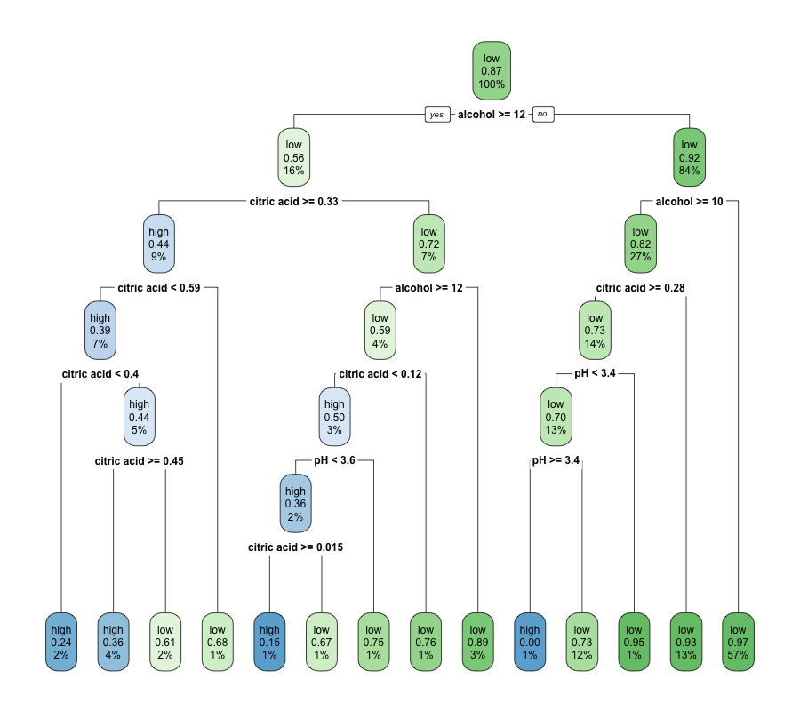

## Reading & Interpreting Decision Trees

- The Predicted Class (*High* or *Low*)
- The Predicted Probability of the positive Class
- The Percentage of observations in this Node

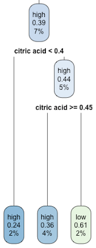

## Evaluating Tree-Based Models

- Regression vs Classification Trees

## Evaluating Tree-Based Models: Regression Trees

- Root Mean Square Error (RMSE)
- R-Squared (& Adjusted R-Squared)
- Explained Variance
- Generally those you would associate with Regression Models

## Evaluating Tree-Based Models: Classification Trees

## Evaluating Tree-Based Models: Classification Trees

- **Sensitivity**, measure of how many positive cases were correctly identified
- **Specificity**, measure of how many negative cases were correctly identified
- **Accuracy**, measure of how many cases overall were correctly identified

## Evaluating Tree-Based Models: Classification Trees

- **Positive Predictive Value**, measure of how many false positive occurred
- **Negative Predictive Value**, measure of how many false negatived occurred

## Questions, Comments and More

- Find me online: thomasjwise.com
- Email me: thomas.j.wise@outlook.com
- Connect with me: www.linkedin.com/in/tjwise213/
- Follow me: @thomasj_wise